Brouillon

# `spatialRegroup` : un package R de correction locale du découpage géographique

Application aux effets de frontière sur la TFPB en Île-de-France

[ISSN 2743-8791 - Rzine.fr - Revue de méthodes pour les SHS](https://rzine.fr/)

Auteur·rice

Affiliation

[Nicolas Ausello](https://rzine.fr)

[Lab. ESPI2R-UMR LADYSS 7533](https://xxxxx.fr)

Date de publication

4 septembre 2026

Doi

10.xxxx/xxx-xxx

Keywords

spatialRegroup, Régionalisation, Fiscalité locale, Modélisation multiniveau, Île-de-France

Résumé

La constitution de partitions territoriales cohérentes est un enjeu central de l’analyse spatiale, qu’il s’agisse d’évaluer la pertinence de découpages administratifs existants ou d’optimiser des regroupements construits par des méthodes de classification non supervisée. Cet article présente `spatialRegroup`, un package R conçu pour corriger localement tout découpage géographique (institutionnel ou *data-driven*) en identifiant les unités frontalières dont le profil attributaire est statistiquement plus proche d’un groupe voisin que de leur groupe d’appartenance, et en procédant à leur réassignation sans altérer la structure globale. Appliqué à la taxe foncière sur les propriétés bâties (TFPB) en Île-de-France (2024), le package mobilise les coefficients locaux d’une régression géographiquement pondérée multiscalaire (MGWR) comme variables d’affinité, capturant l’hétérogénéité spatiale des comportements fiscaux. La validation multiniveau révèle des effets de frontière micro-locaux aux interfaces intercommunales, illustrant l’intérêt du package comme outil de diagnostic territorial des incohérences aux marges des découpages géographiques.

# 1 Introduction

Un des enjeux de l’analyse spatiale des phénomènes sociaux repose sur la capacité à constituer des unités territoriales cohérentes, à la fois homogènes en termes de caractéristiques internes et pertinentes au regard de la thématique abordée. Ce défi de la délimitation territoriale, généralement désigné par le terme MAUP (*Modifiable Areal Unit Problem*) ou problème d’agrégation spatiale, est au cœur d’une littérature en géographie quantitative (Fotheringham et al., 2000; Openshaw, 1984). Deux logiques se distinguent.

La première, celle de la régionalisation contrainte, part des observations individuelles géolocalisées et reconstruit une partition de l’espace *ex nihilo*, sans présupposer aucun découpage préexistant. Le principe consiste à regrouper les unités spatiales élémentaires en zones agrégées de manière à maximiser l’homogénéité interne de chaque zone (au regard des variables considérées) tout en respectant une contrainte de contiguïté géographique, c’est-à-dire en n’agrégeant que des unités voisines les unes des autres. Cette double exigence, de cohésion statistique et de continuité spatiale, distingue ces méthodes d’une simple classification statistique (de type k-*means*), qui ignore la localisation des observations et peut ainsi produire des groupes discontinus dans l’espace. Plusieurs familles d’algorithmes ont été développées pour résoudre ce problème d’optimisation : la classification hiérarchique géographiquement contrainte (Chavent et al., 2018), de l’algorithme SKATER (Assunção et al., 2006) ou des approches REDCAP (Guo, 2008).

La seconde logique, moins outillée, ne cherche pas à créer un découpage mais à évaluer la pertinence d’un découpage existant (Coombes et al., 1986; Farmer et Fotheringham, 2011; Klapka et al., 2013) : dans quelle mesure un découpage institutionnel (EPCI, arrondissement, zone d’emploi) reflète-t-il une réalité socio-spatiale homogène, ou agrège-t-il au contraire des unités dont les profils seraient statistiquement plus proches d’un groupement voisin (Briant et al., 2015; Openshaw, 1984) ?

La distinction entre régions **fonctionnelles** et régions **administratives** structure une partie des travaux en géographie quantitative (Farmer et Fotheringham, 2011; Openshaw, 1984), et trouve une illustration empirique dans les nombreux effets de frontière documentés en fiscalité (Revelli, 2001), sur les marchés immobiliers (Fack et Grenet, 2010; Guérois et Le Goix, 2009) ou dans la concurrence fiscale entre collectivités (Tiebout, 1956).

Cet article propose une présentation du package R `spatialRegroup` d’évaluation et de correction marginale de découpages géographiques existants disponible sur le [CRAN](https://cran.r-project.org/web/packages/spatialRegroup/index.html). Contrairement aux méthodes de régionalisation globale, `spatialRegroup` ne reconstruit pas une partition de zéro : il part d’un découpage géographique donné et identifie les seules unités frontalières dont le profil attributaire est statistiquement plus proche d’un groupe voisin que de leur propre groupe d’appartenance, sur la base de distances euclidiennes calculées dans leur voisinage immédiat.Cette approche locale permet de corriger à la marge les incohérences d’un zonage sans en altérer la structure d’ensemble (Openshaw, 1984), tout en restant utilisable en complément des méthodes de reconstruction globale plutôt qu’en remplacement.

Les variables attributaires mobilisées pour ce calcul d’affinité peuvent être de simples caractéristiques socio-économiques, mais aussi, et c’est un usage que nous illustrons dans cet article, des coefficients issus d’une régression géographiquement pondérée multiscalaire (MGWR) (Fotheringham et al., 2017; Yu et al., 2020). La MGWR permet en effet d’estimer, commune par commune, des coefficients locaux qui rendent compte de l’hétérogénéité spatiale des relations statistiques (Brunsdon et al., 1996; Fotheringham et al., 2002), une hétérogénéité que les seules caractéristiques brutes des unités ne peuvent capturer. Utilisés comme variables d’entrée de `spatialRegroup`, ces coefficients permettent ainsi de fonder la reclassification non plus sur ce que sont les unités, mais sur la manière dont elles se comportent statistiquement vis-à-vis d’un phénomène donné.

Nous illustrons les capacités du package à travers une application à la taxe foncière sur les propriétés bâties (TFPB) en région Île-de-France sur l’année 2024. La TFPB constitue un cas d’application particulièrement pertinent puisque son taux résulte d’une superposition de décisions fiscales communales et intercommunales : l’appartenance d’une commune à un EPCI plutôt qu’un autre produit des effets directs capitalisés dans les prix immobiliers (Fack et Grenet, 2010; Revelli, 2001). Identifier les communes dont le profil fiscal est statistiquement incohérent avec leur EPCI d’appartenance revient ainsi à localiser des effets de frontières au niveau intercommunal.

```r
# Packages nécessaires à la reproduction de la chaîne de traitement

# Chargement et manipulation des données
library(tidyverse)       # Suite pour la manipulation et la visualisation de données
library(magrittr)        # Opérateurs (%>%)
library(purrr)           # Programmation fonctionnelle

# Données spatiales
library(sf)              # Manipulation de données spatiales vectorielles
library(sp)              # Classes spatiales (requis par GWmodel)

# Analyse spatiale et modélisation statistique
library(spdep)           # Autocorrélation spatiale et matrices de voisinage
library(GWmodel)         # Régression géographiquement pondérée (GWR, MGWR)
library(rgeoda)          # Algorithmes de régionalisation contrainte (SKATER, REDCAP, Max-P)
library(lme4)            # Modèles mixtes (effets fixes et aléatoires)
library(spatialRegroup)  # Regroupement spatial local (package présenté dans cet article)

# Visualisation analytique
library(ggplot2)         # Création de graphiques
library(scales)          # Formatage des axes et des échelles
library(ggrepel)         # Étiquettes de texte sans chevauchement
library(ggpubr)          # Extraction et assemblage de légendes ggplot
library(patchwork)       # Assemblage de graphiques ggplot
library(tmap)            # Cartographie thématique

# Packages utilisés pour la mise en page de l'article

library(kableExtra)      # Mise en forme des tableaux HTML
library(sjPlot)          # Tableaux de résultats de modèles HTML (tab_model)
```

# 2 Un package de regroupement local complémentaire aux outils de régionalisation

Un certain nombre de packages R permettent de regrouper des entités géographiques en fonction de variables attributaires en imposant une contrainte de contiguïté spatiale. Les approches les plus répandues relèvent de la **régionalisation globale** : il s’agit de produire une partition de l’ensemble des unités spatiales en $k$ régions homogènes, construites de zéro. C’est le cas de la fonction `skater()` du package `spdep`, fondée sur la suppression d’arêtes d’un arbre couvrant minimal construit à partir des dissimilarités entre unités voisines (Assunção et al., 2006). Le package `rgeoda` (Li et Anselin, 2022) propose quant à lui un ensemble d’algorithmes de régionalisation contraints (SKATER, REDCAP (Guo, 2008), Max-P), offrant une palette plus large mais relevant du même paradigme. Parmi ces algorithmes, Max-P (Duque et al., 2012) se distingue en ne fixant pas le nombre de régions $k$ *a priori* : il maximise le nombre de régions spatialement contiguës sous la contrainte qu’un seuil minimum d’unités soit respecté dans chaque région, ce qui contrôle indirectement leur taille et leur cohérence interne.

Les approches que nous prenons ici comme exemple partagent néanmoins une limite commune : elles reconstruisent intégralement la partition à partir des observations individuelles, sans tenir compte d’un éventuel découpage préexistant. `spatialRegroup` se positionne en complément de ces méthodes : plutôt que de substituer une nouvelle partition à une partition existante, il procède à une correction locale en identifiant les unités frontalières dont le profil attributaire est statistiquement plus proche d’un groupe voisin que de leur groupe d’appartenance, et en les réassignant sans modifier le découpage global. Il devient utile dans des situations où une partition de référence, institutionnelle ou *data-driven* (découpage géographique construit directement à partir des données), doit être affinée à la marge plutôt que reconstruite de zéro.

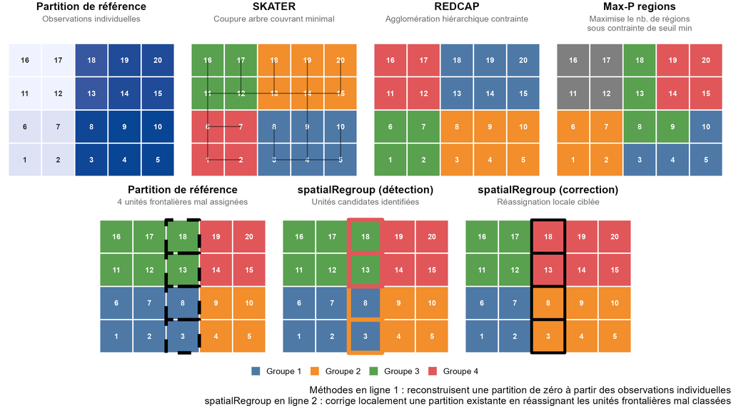

Figure 1 : Comparaison de quatre approches de regroupement d’entités spatiales (Auteur, 2026)

Sur cet exemple (figure 1), les cellules 3, 8, 13 et 18 ont été construites avec un profil attributaire délibérément incohérent avec leur groupe d’appartenance. SKATER, REDCAP et Max-P les ignorent car ils reconstruisent la partition de zéro sans référence au découpage initial, produisant des partitions globalement cohérentes mais sans capacité à corriger des anomalies frontalières au sein d’un découpage existant. `spatialRegroup`, partant de la partition de référence, identifie ces quatre cellules comme candidates et les réaffecte correctement vers leur groupe d’affinité attributaire, sans modifier les unités non frontalières.

| Critère | Max-P | SKATER | REDCAP | spatialRegroup |
| --- | --- | --- | --- | --- |
| Partition initiale requise | Non | Non | Non | Oui |
| k groupes à fixer | Non | Oui | Oui | Non |
| Unités traitées | Toutes | Toutes | Toutes | Frontalières |
| Traitement des isolats | Non | Non | Non | Oui |
| Validation multiniveaux | Non | Non | Non | Oui |

Tableau 1 : Comparaison de `spatialRegroup` avec les principales méthodes de régionalisation contrainte disponibles dans R (Auteur, 2026).

`spatialRegroup` se distingue donc des trois approches prises en exemple en ne construisant pas de matrice globale : la dissimilarité est calculée localement pour chaque unité frontalière, en comparant sa distance euclidienne moyenne aux unités intra-groupe et extra-groupe dans son voisinage immédiat. Ce calcul local évite les effets d’échelle propres aux matrices globales et préserve la structure spatiale initiale pour les unités intérieures. Contrairement aux méthodes de régionalisation globale présentées précédemment, cette approche part d’un découpage existant et n’intervient que là où ce découpage apparaît statistiquement incohérent. L’idée centrale repose sur la notion d’**effet de frontière** : une unité spatiale est considérée comme mal classée dans son groupe d’appartenance lorsque son profil attributaire est plus proche de celui des unités voisines appartenant à un groupe adjacent que de celui de ses propres voisins intra-groupe. Le fonctionnement `spatialRegroup` repose sur trois étapes distinctes des approches citées (figure 2) :

1. **Le point de départ est une partition existante** (dans l’exemple qui suit, les Établissements Publics de Coopération Intercommunale, EPCI) dont la structure est conservée pour les unités bien classées.
2. **Seules les unités frontalières** (celles qui sont en contact avec un groupement voisin différent) sont candidates à la reclassification, sur la base de leur distance euclidienne aux profils attributaires moyens des groupes adjacents.
3. **Un mécanisme de traitement des isolats** réintègre dans leur groupe d’origine les unités candidates qui se retrouveraient seules après reclassification, garantissant la cohérence géographique du résultat.

Enfin, `spatialRegroup` intègre nativement des outils de validation par modèles multiniveaux : la comparaison des AIC entre la partition initiale et la partition recomposée permet de mesurer si le regroupement corrigé explique mieux la variable d’intérêt que le découpage géographique de départ.

**NoteL’AIC : signal de la pertinence géographique du regroupement**

L’AIC (*Akaike Information Criterion*) permet de comparer des modèles concurrents en mesurant leur qualité d’ajustement aux données, pénalisée par leur complexité. Un AIC plus bas indique un modèle préférable.

Dans le cadre des modèles multiniveaux, il permet ainsi de déterminer quelle structure de regroupement capture le mieux la variance observée, sans surajuster les données par l’ajout de paramètres superflus.

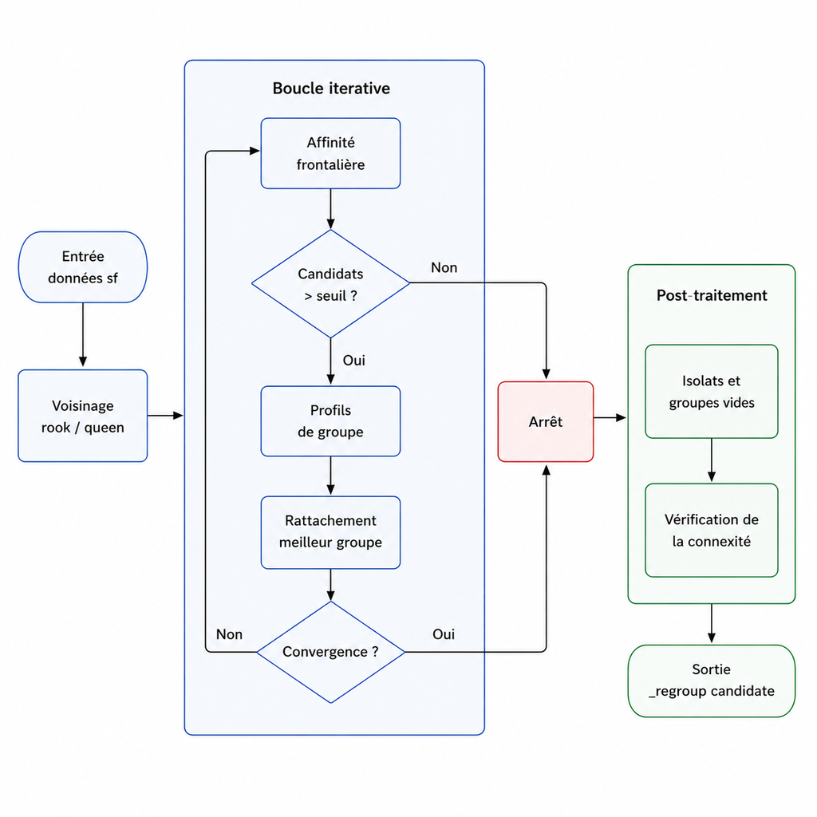

Figure 2 : Boucle itérative et post-traitement du package spatialRegroup (Auteur, 2026)

Une série de travaux en modélisation spatiale ont pour objectifs d’identifier des contextes spatiaux spécifiques au sein desquels la relation entre différents phénomènes n’est pas la même que dans d’autres, afin de formuler des recommandations en matière de politiques publiques. Les méthodes de régression géographiquement pondérée (GWR, Brunsdon et al., 1996; Fotheringham et al., 2002) s’inscrivent dans cette démarche : en estimant des coefficients locaux unité par unité, elles permettent de cartographier des variations spatiales de la relation entre une variable d’intérêt et ses déterminants.

Ces contextes spatiaux ainsi identifiés peuvent alors alimenter une modélisation multiniveau, dont la limite structurelle réside précisément dans la nécessité de définir les niveaux d’agrégation *a priori*, le plus souvent sur la base de découpages administratifs. En estimant des modèles GWR en amont, il devient possible de délimiter des contextes directement dérivés des données (*data-driven*), s’affranchissant ainsi de ce présupposé (Feuillet, 2021). Cette approche hybride GWR-multiniveau construit un maillage de l’espace géographique qui ne coïncide pas nécessairement avec les découpages administratifs qui structurent l’action publique (Feuillet et al., 2024; Mangeney et al., 2024).

Dans cette même logique mais de manière différente, `spatialRegroup` offre la possibilité de tester la validité d’un regroupement d’observations au regard du processus géographique étudié, tout en ménageant la possibilité que le découpage existant demeure pertinent. Le package produit un diagnostic plutôt qu’une remise en cause systématique des partitions de départ. L’enjeu est donc d’identifier les unités spatiales (communes, quartiers ou toute autre maille choisie par l’analyste) qui se révèlent statistiquement plus proches d’un groupement voisin que de leur propre groupement d’appartenance. En mobilisant les coefficients locaux issus d’une GWR comme variables d’affinité, le package traduit les résultats d’une GWR en une évaluation de la partition de départ : là où les inadéquations sont avérées, il ouvre la possibilité d’une reconfiguration territoriale ciblée ; là où elles sont absentes, il confirme la pertinence du découpage existant.

# 3 Application du Package `spatialRegroup` : les effets de contexte sur la taxe foncière bâti (TFB) en région Île-de-France

Nous proposons une application de `spatialRegroup` à la taxe foncière sur les propriétés bâties (TFPB) en région Île-de-France pour l’année 2024. Ce cas d’application est particulièrement adapté car le taux de TFPB effectivement supporté par les propriétaires résulte d’une superposition de décisions communales et intercommunales. L’appartenance d’une commune à un EPCI plutôt qu’un autre produit donc des effets fiscaux directs. Identifier les communes dont le profil est statistiquement incohérent avec leur EPCI d’appartenance revient à localiser des zones de friction aux frontières intercommunales. Avant d’appliquer le package, nous esquissons brièvement la structure institutionnelle qui détermine ces effets.

## 3.1 Les régimes fiscaux sur la propriété en Île-de-France

```r
fichiers_shp <- list(
  communes = "https://zenodo.org/records/21307967/files/communes.zip"
)

options(timeout = 3600)

dir.create("data", showWarnings = FALSE)
dir.create("data/shp", showWarnings = FALSE)

for (nom in names(fichiers_shp)) {
  dest <- paste0("data/shp/", basename(fichiers_shp[[nom]]))
  if (!file.exists(dest)) {
    download.file(fichiers_shp[[nom]], destfile = dest, mode = "wb")
  }

  if (!file.exists("data/communes.shp")) {
    unzip(dest, exdir = "data")
  }
}
```

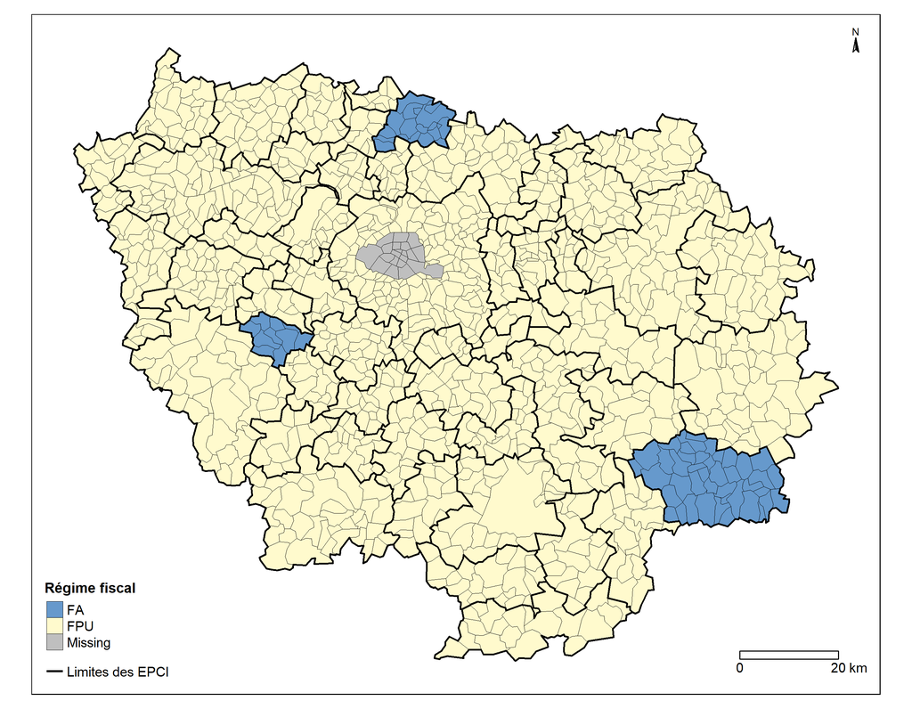

Figure 3 : Cartes des régimes fiscaux des EPCI franciliens (Auteur, 2026, source : DGCL/Département des études et des statistiques locales, 2026)

## 3.2 Les données retenues

Dans le cadre de l’application du package `spatialRegroup` au cas de la fiscalité sur la propriété immobilière, nous mobilisons quatre jeux de données pour les communes d’Île-de-France, à l’exclusion de Paris. Cette exclusion se justifie par le statut administratif singulier de Paris par rapport aux autres Etablissement publics territoriaux (EPT) et EPCI, et dont la taille constituerait un effet levier démesuré sur les paramètres de l’algorithme. Le périmètre retenu couvre ainsi les sept départements de grande et petite couronne (77, 78, 91, 92, 93, 94, 95), pour un échantillon de 1250 communes disposant de données complètes sur l’ensemble des variables.

- **Les données Demandes de Valeurs Foncières (DVF)**, issues de la base *open data* de la Direction Générale des Finances Publiques, renseignent l’ensemble des transactions immobilières enregistrées entre 2021 et 2024. Après filtrage sur la nature des mutations (ventes uniquement) et le type de bien (maisons et appartements), les valeurs aberrantes sont exclues selon des seuils raisonnés : prix compris entre 15 000 € et 5 000 000 €, surface entre 10 et 350 m² (200 m² pour les appartements), et prix au m² entre 330 € et 10 000 €. Ces seuils visent à éliminer les transactions multiventes et les enregistrements erronés sans tronquer la distribution des marchés les plus tendus de l’agglomération (Mericskay et Demoraes, 2022). Le recours à quatre années consécutives, plutôt qu’à une seule, permet de stabiliser les estimations communales du prix moyen au m² (prix_m2_moy), particulièrement nécessaire pour les communes à faible volume de transactions.
- **Les données de fiscalité locale**, transmises annuellement par la DGFiP aux services de l’État, fournissent le taux global de taxe foncière sur les propriétés bâties (Taux_Global_TFB) pour chaque commune pour l’exercice fiscal de l’année 2024. Ce taux global agrège le taux communal et le taux additionnel intercommunal, reflétant ainsi directement l’effet de l’appartenance à un EPCI sur la charge fiscale des propriétaires. Le taux 2024 (Taux_TFB_2024) est retenu comme variable d’intérêt principale dans la modélisation, en raison de sa plus grande proximité avec les effets institutionnels récents liés aux processus d’harmonisation fiscale intercommunale.
- **La Base Permanente des Équipements (BPE) de l’INSEE** recense l’offre d’équipements et de services à la population par commune. Afin de lisser les effets conjoncturels, le nombre d’équipements est calculé comme la moyenne des millésimes 2019 et 2024 (moy_equip). Cette variable témoigne de l’attractivité et du niveau de service d’une commune, déterminant supposé de la pression fiscale locale et de la demande résidentielle (Tiebout, 1956).
- **Les données de revenus de l’INSEE**, issues du dispositif Filosofi, fournissent le revenu médian par unité de consommation à l’échelle communale pour l’année 2021 (median). Le revenu médian est le principal déterminant socio-économique du taux de TFPB retenu ici : il conditionne à la fois la capacité contributive des ménages et la sensibilité politique aux décisions fiscales locales.

Ces quatre sources sont agrégées à l’échelon communal pour constituer la base de travail finale (`df_final`), téléchargeable ci-dessous. Le code ci-après documente l’intégralité de la chaîne de prétraitement ayant permis de construire ce fichier — téléchargement des données brutes depuis Zenodo, nettoyage des DVF et jointures finales. Il n’est pas ré-exécuté au rendu de l’article (`eval=FALSE`) car `df_final.rds` est chargé directement via `readRDS()`.

```r
# Téléchargement des données brutes (Zenodo)

options(timeout = 3600)
dir.create("data",     showWarnings = FALSE)
dir.create("data/shp", showWarnings = FALSE)

# Données
fichiers <- list(
  bpe          = "https://zenodo.org/records/21261696/files/bpe.csv",
  epci_com_idf = "https://zenodo.org/records/21261696/files/codes_epci-com.csv",
  dvf21        = "https://zenodo.org/records/21261696/files/dvf2021.csv",
  dvf22        = "https://zenodo.org/records/21261696/files/dvf2022.csv",
  dvf23        = "https://zenodo.org/records/21261696/files/dvf2023.csv",
  dvf24        = "https://zenodo.org/records/21261696/files/dvf2024.csv",
  rev_21       = "https://zenodo.org/records/21261696/files/revenu_2021.csv",
  ept_idf      = "https://zenodo.org/records/21261696/files/ept_IDF.csv",
  fisc         = "https://zenodo.org/records/21261696/files/fiscalite_locale_21-24.csv"
)

for (nom in names(fichiers)) {
  dest <- paste0("data/", basename(fichiers[[nom]]))
  if (!file.exists(dest)) download.file(fichiers[[nom]], destfile = dest, mode = "wb")
}

# Fond de carte communes (shapefile)
communes_zip <- "data/shp/communes.zip"
if (!file.exists(communes_zip)) {
  download.file(
    "https://zenodo.org/records/21307967/files/communes.zip",
    destfile = communes_zip, mode = "wb"
  )
  unzip(communes_zip, exdir = "data")
}

# Chargement des données

dvf21 <- readr::read_csv("data/dvf2021.csv", locale = readr::locale(encoding = "UTF-8"))
dvf22 <- readr::read_csv("data/dvf2022.csv", locale = readr::locale(encoding = "UTF-8"))
dvf23 <- readr::read_csv("data/dvf2023.csv", locale = readr::locale(encoding = "UTF-8"))
dvf24 <- readr::read_csv("data/dvf2024.csv", locale = readr::locale(encoding = "UTF-8"))

bpe          <- readr::read_csv("data/bpe.csv")
fisc         <- readr::read_csv("data/fiscalite_locale_21-24.csv", locale = readr::locale(encoding = "UTF-8"))
rev_21       <- readr::read_csv("data/revenu_2021.csv",            locale = readr::locale(encoding = "UTF-8"))
epci_com_idf <- readr::read_csv("data/codes_epci-com.csv",         locale = readr::locale(encoding = "UTF-8"))
ept_idf      <- readr::read_csv("data/ept_IDF.csv",                locale = readr::locale(encoding = "UTF-8"))
com          <- sf::read_sf("data/communes.shp")

# Nettoyage et agrégation des DVF (2021-2024)

nettoyer_dvf <- function(DVF) {
  DVF |>
    dplyr::filter(nature_mutation == "Vente",
                  type_local %in% c("Maison", "Appartement")) |>
    rename(
      id          = id_mutation,
      codecommune = code_commune,
      type        = type_local,
      surface     = surface_reelle_bati,
      piece       = nombre_pieces_principales,
      prix        = valeur_fonciere
    ) |>
    mutate(across(c(prix, surface, piece), as.numeric)) |>
    dplyr::filter(!is.na(prix)) |>
    group_by(id) |> dplyr::filter(n() == 1) |> ungroup() |>
    dplyr::filter(dplyr::between(prix, 15000, 5000000)) |>
    dplyr::filter(
      case_when(type == "Appartement" ~ dplyr::between(surface, 10, 200),
                type == "Maison"      ~ dplyr::between(surface, 10, 350),
                TRUE                  ~ FALSE)
    ) |>
    mutate(prixm2 = prix / surface) |>
    dplyr::filter(dplyr::between(prixm2, 330, 10000))
}

datasets      <- list(dvf21 = dvf21, dvf22 = dvf22, dvf23 = dvf23, dvf24 = dvf24)
dvf_nettoyes  <- lapply(datasets, nettoyer_dvf)

dvf_communes <- lapply(dvf_nettoyes, function(dvf) {
  dvf |>
    group_by(codecommune) |>
    summarise(nb_ventes = n(), prixm2 = mean(prixm2, na.rm = TRUE), .groups = "drop")
})

# Construction du fichier de travail final

# Moyenne des équipements 2019-2024 (BPE)
bpe1 <- bpe |>
  group_by(GEO, TIME_PERIOD) |>
  summarise(nb_equipements = sum(OBS_VALUE, na.rm = TRUE), .groups = "drop") |>
  pivot_wider(names_from = TIME_PERIOD, values_from = nb_equipements, values_fill = 0) |>
  mutate(moy_equip = (`2019` + `2024`) / 2)

# Codes EPCI avec intégration des EPT franciliens
epci_com_idf <- epci_com_idf |>
  left_join(ept_idf |> dplyr::select(Code.Officiel.Commune, Code.Officiel.EPT),
            by = "Code.Officiel.Commune") |>
  mutate(`Code Officiel EPCI` = if_else(!is.na(Code.Officiel.EPT),
                                         Code.Officiel.EPT, Code.Officiel.EPCI)) |>
  dplyr::select(-Code.Officiel.EPT)

# Taux TFPB moyens par commune
taux_moyen <- com |>
  sf::st_drop_geometry() |>
  left_join(fisc, by = c("DCOE_C_COD" = "INSEE.COM")) |>
  group_by(DCOE_C_COD) |>
  summarise(
    Taux_TFB_2021 = mean(Taux_Global_TFB[EXERCICE == 2021], na.rm = TRUE),
    Taux_TFB_2022 = mean(Taux_Global_TFB[EXERCICE == 2022], na.rm = TRUE),
    Taux_TFB_2023 = mean(Taux_Global_TFB[EXERCICE == 2023], na.rm = TRUE),
    Taux_TFB_2024 = mean(Taux_Global_TFB[EXERCICE == 2024], na.rm = TRUE),
    Taux_TFB_moy  = mean(Taux_Global_TFB, na.rm = TRUE)
  )

# Base spatiale : communes + revenus + taux TFPB
df_reduit <- com |>
  left_join(rev_21,     by = c("DCOE_C_COD" = "Code")) |>
  left_join(taux_moyen, by = "DCOE_C_COD") |>
  sf::st_make_valid() |>
  distinct(DCOE_C_COD, .keep_all = TRUE) |>
  dplyr::select(DCOE_C_COD, median, Taux_TFB_2021, Taux_TFB_2022,
                Taux_TFB_2023, Taux_TFB_2024, Taux_TFB_moy,
                EPCI_CODE, REGION_COD, DDEP_C_COD, geometry)

# Jointure des prix DVF par année
annees <- c("dvf21" = "2021", "dvf22" = "2022", "dvf23" = "2023", "dvf24" = "2024")
df_final <- df_reduit
for (key in names(annees)) {
  df_final <- df_final |>
    left_join(
      dvf_communes[[key]] |>
        rename_with(~ paste0(., "_", annees[[key]]), c("prixm2", "nb_ventes")),
      by = c("DCOE_C_COD" = "codecommune")
    )
}

df_final <- df_final |>
  mutate(
    prix_m2_moy = rowMeans(
      cbind(prixm2_2021, prixm2_2022, prixm2_2023, prixm2_2024), na.rm = TRUE),
    nb_ventes_total = rowSums(
      cbind(nb_ventes_2021, nb_ventes_2022, nb_ventes_2023, nb_ventes_2024), na.rm = TRUE)
  ) |>
  dplyr::filter(!is.na(prix_m2_moy))

# Intégration des codes EPCI/EPT, équipements, exclusion Paris et NA revenus
epci_com_idf$Code.Officiel.Commune <- as.character(epci_com_idf$Code.Officiel.Commune)

df_final <- df_final |>
  rename(codecommune = DCOE_C_COD) |>
  left_join(epci_com_idf, by = c("codecommune" = "Code.Officiel.Commune")) |>
  rename(EPCI = `Code Officiel EPCI`) |>
  mutate(EPCI = as.factor(EPCI)) |>
  left_join(bpe1, by = c("codecommune" = "GEO")) |>
  dplyr::filter(!startsWith(DDEP_C_COD, "75")) |>
  dplyr::filter(!is.na(median))

saveRDS(df_final, file = "data/df_final.rds")
```

| Variable | N | Minimum | Q25 | Médiane | Moyenne | Q75 | Maximum | Éc. type | IQR |
| --- | --- | --- | --- | --- | --- | --- | --- | --- | --- |
| Taux TFB 2024 | 1250 | 14.55 | 31.94 | 37.42 | 37.47 | 42.42 | 67.95 | 8.19 | 10.48 |
| Revenu médian (€) | 1250 | 14790.00 | 24882.50 | 27105.00 | 27350.93 | 29527.50 | 48010.00 | 4255.42 | 4645.00 |
| Équipements (moy.) | 1250 | 1.50 | 11.00 | 22.50 | 36.17 | 56.50 | 126.50 | 32.21 | 45.50 |
| Prix m² moyen (€) | 1250 | 1121.44 | 2568.98 | 3141.79 | 3247.07 | 3659.27 | 8367.21 | 1076.21 | 1090.29 |

Tableau 2 : Statistiques descriptives des variables retenues (source : DVF, 2021-2024 ; DGFiP, 2024 ; Insee, 2019-2024)

# 4 Exploration de l’hétérogénéité spatiale des relations statistiques entre le taux voté de la TFB et ses déterminants supposés

Une première approche consisterait à alimenter `spatialRegroup` directement avec les variables brutes retenues et à laisser l’algorithme identifier les communes frontalières mal classées sur cette base. Cette stratégie présente cependant une limite : elle suppose que la relation entre ces variables et le taux de TFB est spatialement stationnaire, c’est-à-dire identique sur l’ensemble du territoire francilien. Or, on peut faire l’hypothèse qu’en Île-de-France, les dynamiques fiscales et foncières sont dépendantes de contextes locaux : l’effet du revenu médian sur le taux de TFB n’est pas le même dans les communes rurales de Seine-et-Marne que dans les communes denses de petite couronne. De même, l’effet des prix immobiliers sur la fiscalité locale varie selon la tension du marché, le profil socio-fiscal de l’EPCI d’appartenance et la trajectoire historique des taux (Brunsdon et al., 1996; Fotheringham et al., 2002). Utiliser les valeurs brutes de ces variables reviendrait donc à ignorer cette hétérogénéité spatiale et à traiter comme équivalentes des situations territoriales différentes. La régression géographiquement pondérée multiscalaire (MGWR) répond précisément à cette limite (Fotheringham et al., 2017; Yu et al., 2020). Contrairement à la régression linéaire classique, qui estime un coefficient unique pour l’ensemble du territoire, et à la GWR standard (Brunsdon et al., 1996), qui impose la même bande passante à toutes les variables, la MGWR estime pour chaque commune et pour chaque variable explicative un coefficient local spécifique, dont la bande passante optimale est déterminée indépendamment par minimisation de l’AIC (Fotheringham et al., 2017).

**NoteLa régression géographiquement pondérée**

Dans une GWR, les observations individuelles, proches du point de référence *i*, exerceraient une influence plus importante sur celui-ci que les observations qui en sont éloignées. Sur la base de ce principe, la pondération du modèle de régression GWR accordée à chaque observation est décroissante en fonction de sa distance au point *i*. Deux principaux paramètres sont déterminés par le modèle :

- la **fenêtre** (*bandwidth*), qui désigne la largeur du périmètre située autour de *i* au-delà duquel l’influence des observations est estimée faible ou nulle (défini par rapport au nombre des plus proches voisins ou par une distance)
- le **noyau**, qui renvoie au type de fonction utilisé pour déterminer la pondération des observations situées dans la fenêtre sur *i*.

L’opération de calcul est ainsi répétée pour chaque observation individuelle *xy*.

Dans le cadre de cet article, la MGWR est donc mobilisée pour estimer, commune par commune, la sensibilité du taux de TFB voté aux trois variables explicatives retenues : le revenu médian (`coef_revenu`), le prix moyen au m² (`coef_prix`) et le nombre moyen d’équipements (`coef_equip`). Ces coefficients locaux, complétés par l’intercept local (`Intercept`), constituent non pas une mesure des variables elles-mêmes, mais une caractérisation de l’hétérogénéité spatiale des relations statistiques entre la fiscalité foncière et ses déterminants supposés (Yu et al., 2020).

```r
df_complet <- df_final %>%
  drop_na(log_median)  # Supprime uniquement les lignes où `median` est NA

centroides <- st_centroid(df_complet)
coords <- st_coordinates(centroides)

df_complet$X <- coords[, 1]
df_complet$Y <- coords[, 2]

data_model <- df_complet %>%
  st_drop_geometry() %>%
  dplyr::  select(log_Taux_TFB_2024,log_moy_equip, log_prix_m2_moy, log_median, X, Y) %>%
  na.omit()

coords_model <- as.matrix(data_model[, c("X", "Y")])

# Matrice de coordonnées
sp_data <- SpatialPointsDataFrame(
  coords = coords_model,
  data   = data_model,
  proj4string = CRS("+init=epsg:2154")
)

bw_opt <- bw.gwr(
  formula  =log_Taux_TFB_2024 ~ log_moy_equip + log_prix_m2_moy + log_median,
  data     = sp_data,
  approach = "AICc",
  kernel   = "bisquare",
  adaptive = TRUE   # bande passante adaptative
)

mgwr_result <- gwr.multiscale(
  formula  = log_Taux_TFB_2024 ~ log_moy_equip + log_median + log_prix_m2_moy,
  data     = sp_data,
  kernel   = "bisquare",
  adaptive = TRUE,
  bws0     = c(20, 20, 20, 20),
  max.iterations = 10,
  verbose = TRUE
)

saveRDS(mgwr_result, "data/mgwr_result.rds")
```

```
   *                       Package   GWmodel                             *
   Program starts at: 2026-05-28 21:29:54.434943
   Call:
   gwr.multiscale(formula = log_Taux_TFB_2024 ~ log_moy_equip +
    log_median + log_prix_m2_moy, data = sp_data, kernel = "bisquare",
    adaptive = TRUE, max.iterations = 10, bws0 = c(20, 20, 20,
        20), verbose = TRUE)

   Dependent (y) variable:  log_Taux_TFB_2024
   Independent variables:  log_moy_equip log_median log_prix_m2_moy
   Number of data points: 1250
   *                       Multiscale (PSDM) GWR                          *

   *********************Model calibration information*********************
   Kernel function: bisquare
   Adaptive bandwidths for each coefficient(number of nearest neighbours):
              (Intercept) log_moy_equip log_median log_prix_m2_moy
   Bandwidth           29           181        109             133

   ****************Summary of GWR coefficient estimates:******************
                         Min.    1st Qu.     Median    3rd Qu.    Max.
   Intercept       -2.9120566  4.5269942  6.1689175  7.1708516 10.5820
   log_moy_equip    0.0099748  0.0480860  0.0652885  0.0843071  0.1480
   log_median      -0.5291585 -0.2607979 -0.1005820  0.0395163  0.6370
   log_prix_m2_moy -0.7321837 -0.4091146 -0.0389658  0.0727811  0.2608
   ************************Diagnostic information*************************
   Number of data points: 1250
   Effective number of parameters (2trace(S) - trace(S'S)): 226.7756
   Effective degrees of freedom (n-2trace(S) + trace(S'S)): 1023.224
   AICc value:  -1398.362
   AIC value:  -1616.182
   BIC value:  -1855.967
   Residual sum of squares:  17.60631
   R-square value:  0.7272041
   Adjusted R-square value:  0.6666856

   Program stops at: 2026-05-28 22:32:48.546171
```

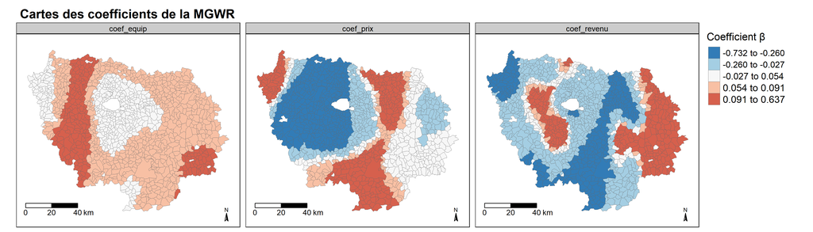

Figure 4 : Cartes des coefficients de la MGWR

**NoteLecture des coefficients β**

Le modèle est log-log (log du taux de TFPB en fonction du log des déterminants), ce qui permet d’interpréter les coefficients comme suit : un coefficient b signifie qu’une hausse de 1 % de la variable explicative est associée à une variation de b % du taux de TFPB, toutes choses égales par ailleurs.

# 5 Paramétrage de la fonction `spatialRegroup`

La fonction `spatialRegroup` expose plusieurs paramètres qui permettent d’ajuster finement la logique de reclassification selon le contexte thématique et la structure spatiale des données.

**Les variables attributaires et leur pondération**. L’argument `vars_attr` désigne le vecteur de variables quantitatives sur lesquelles repose le calcul d’affinité entre unités spatiales. Par défaut, ces variables sont préalablement standardisées `(standardize = TRUE)`, ce qui garantit leur comparabilité indépendamment de leur échelle de mesure. Il est en outre possible d’attribuer un poids différencié à chaque variable *via* l’argument `weights` (vecteur de même longueur que `vars_attr`), afin de refléter des priorités thématiques : par exemple, accorder davantage d’importance à un indicateur socio-économique jugé central dans la définition des territoires fonctionnels.

**Le seuil d’affinité et le profil local**. Le paramètre `threshold` fixe le seuil minimal d’affinité attributaire qu’une unité doit présenter avec un groupe voisin pour être identifiée comme candidate à la reclassification. Un seuil plus élevé rend la procédure plus sélective. Lorsque `local_profile = TRUE` (valeur par défaut), l’affinité d’un candidat est calculée non pas par rapport au centroïde global du groupe cible, mais par rapport au profil des seuls membres de ce groupe qui lui sont géographiquement adjacents, ce qui s’avère plus représentatif dans le cas de groupes spatialement étendus et hétérogènes.

**Les critères d’arrêt**. L’argument `iterations` contrôle le nombre maximal de passes de reclassification. À chaque itération, les unités reclassées peuvent modifier la composition des groupes et déclencher de nouveaux transferts. L’argument `cohesion_tol` introduit un critère d’arrêt anticipé fondé sur la progression de la cohésion interne des groupes, mesurée par le η² (rapport de corrélation). Si le gain de cohésion entre deux itérations successives est inférieur à ce seuil, l’algorithme s’interrompt, évitant des itérations supplémentaires inutiles.

**La gestion des isolats et la taille minimale de groupe**. L’option `remove_isolates = TRUE` réintègre dans leur groupe d’origine les candidats qui, après reclassification, se retrouveraient géographiquement isolés (sans voisin appartenant au même groupe), ce qui préserve la contiguïté spatiale des partitions produites. Le paramètre `min_group` fixe une taille minimale pour qu’un groupe puisse recevoir de nouvelles unités, permettant d’écarter de petits groupes résiduels comme destinations de rattachement.

**Le type de voisinage**. Enfin,`nb_type` spécifie la règle de contiguïté spatiale utilisée pour construire le graphe de voisinage : la contiguïté “queen” (partage d’un point ou d’un segment) ou “rook” (partage d’un segment uniquement), ce dernier étant plus restrictif et adapté à des maillages dont les frontières communes sont toujours linéaires.

## 5.1 Recherche du meilleur paramétrage de `spatialRegroup` en faisant varier le seuil de dissimilarité

Lorsque `spatialRegroup` reclassifie un nombre très faible de communes, le découpage recomposé reste quasi-identique à la partition administrative originelle : les EPCI regroupés ne diffèrent donc du découpage initial que de manière marginale, si bien que les deux modèles multiniveaux — celui estimé sur les EPCI d’origine et celui estimé sur les EPCI recomposés — capturent une structure hiérarchique presque identique. Leurs AIC convergent mécaniquement. À l’inverse, à mesure que le nombre de reclassifications croît, la partition recomposée s’éloigne progressivement du découpage institutionnel de référence. Les communes transférées d’un EPCI à un autre modifient la composition attributaire des groupes, mais aussi, potentiellement, leur cohérence vis-à-vis de la variable d’intérêt. Lorsque ces transferts sont trop nombreux, le modèle multiniveau ajusté sur la partition recomposée peut expliquer moins bien la variance que le modèle de référence, l’écart AIC devient alors positif. En somme, plus l’on réassigne de communes, plus l’on séloigne du découpage de départ et moins l’AIC du modèle fondée sur le nouveau regroupement a de probabilités d’être est meilleur.

Cette relation entre amplitude des reclassifications et évolution de l’AIC constitue donc le comportement de fond à partir duquel les déviations de la tendance globale deviennent intéressantes : ce n’est pas tant la tendance globale qui importe que les paramétrages qui permettent de s’en écarter. Nous prenons ici comme paramètres d’ajustement les valeurs du seuil de dissimilarité (`threshold`) pour lesquelles un nombre donné de reclassifications produit un écart d’AIC supérieur ou inférieur à ce que prédit la relation moyenne, signalant ainsi des configurations territoriales où la frontière administrative est soit particulièrement coûteuse, soit au contraire statistiquement défendable.

**NotePrincipe du seuil de dissimilarité**

Le seuil est la distance maximale tolérée entre le profil attributaire d’une commune candidate et le profil moyen du groupe voisin vers lequel elle pourrait être réassignée.

Nous mettons en place boucle qui balaye 13 valeurs de seuil (0,10 à 0,22) et ajuste pour chacune deux modèles multiniveaux sur la partition originale et sur la partition recomposée, afin de sélectionner le paramétrage qui minimise l’AIC.

```r
vars_attr <- c("coef_prix", "coef_revenu", "coef_equip")

thresholds <- seq(0.1, 0.22, by = 0.01)

results_grid <- map_dfr(thresholds, function(thr) {

# spatialRegroup
  res <- tryCatch(
    spatialRegroup(
      data            = df_final3,
      group_var       = "EPCI",
      vars_attr       = vars_attr,
      method          = "euclidean",
      threshold       = thr,
      standardize     = TRUE,
      iterations      = 10,
      min_group       = 2,
      nb_type         = "rook",
      remove_isolates = TRUE,
      weights         = c(0.1, 0.1, 0.1),
      local_profile   = T,
      cohesion_tol    = 0.001,
      verbose         = F
    ),
    error = function(e) NULL
  )

if (is.null(res)) return(tibble(threshold = thr, aic_orig = NA, aic_final = NA,
                                delta_aic = NA_real_, n_reclass = NA, n_epci_final = NA))

# Construction du dataframe final
  df_tmp <- res |>
    mutate(EPCI_final = if_else(candidate,
                                as.character(EPCI_regroup),
                                as.character(EPCI)))

# Modèles multiniveaux
  m_orig  <- tryCatch(lmer(log_Taux_TFB_2024 ~   log_median + log_prix_m2_moy + log_moy_equip + (1 | EPCI),       data = df_tmp, REML = TRUE), error = function(e) NULL)
  m_final <- tryCatch(lmer(log_Taux_TFB_2024 ~  log_median + log_prix_m2_moy + log_moy_equip + (1 | EPCI_final), data = df_tmp, REML = TRUE), error = function(e) NULL)

  aic_orig  <- if (!is.null(m_orig))  AIC(m_orig)  else NA
  aic_final <- if (!is.null(m_final)) AIC(m_final) else NA

  tibble(
    threshold    = thr,
    aic_orig     = aic_orig,
    aic_final    = aic_final,
    delta_aic    = aic_final - aic_orig,
    n_reclass    = sum(res$candidate, na.rm = TRUE),
    n_epci_final = n_distinct(df_tmp$EPCI_final)
  )
}, .progress = TRUE)

# Format long pour superposer les deux AIC
results_long <- results_grid |>
  pivot_longer(cols = c(aic_orig, aic_final),
               names_to  = "model",
               values_to = "AIC") |>
  mutate(model = recode(model,
                        aic_orig  = "EPCI original",
                        aic_final = "EPCI recomposé"))

# Meilleur threshold (delta_aic le plus bas)
best_thr <- results_grid |> slice_min(delta_aic, n = 1)

best_thes <- ggplot(results_long, aes(x = threshold, y = AIC, color = model, group = model)) +

# Courbes AIC
  geom_line(linewidth = 1) +
  geom_point(size = 2.5) +

# Ligne verticale sur le meilleur threshold
  geom_vline(xintercept = best_thr$threshold,
             linetype = "dashed", color = "grey40", linewidth = 0.8) +
  annotate("label",
           x     = best_thr$threshold,
           y     = max(results_long$AIC, na.rm = TRUE),
           label = paste0("Meilleur seuil"),
           size  = 3.2, color = "grey30", fill = "white", label.size = 0.3) +

# Axe secondaire : nombre de communes reclassées
  geom_line(data = results_grid,
            aes(x = threshold, y = rescale(n_reclass,
                  to = range(results_long$AIC, na.rm = TRUE))),
            inherit.aes = FALSE,
            color = "grey60", linetype = "dotted", linewidth = 0.8) +

  scale_x_continuous(breaks = thresholds, labels = scales::number_format(accuracy = 0.01)) +
  scale_color_manual(values = c("EPCI original" = "#e74c3c",
                                "EPCI recomposé" = "#3498db")) +
  labs(
    caption = "Ligne pointillée grise = nb. communes reclassées (axe normalisé)",
    x        = "Seuil (threshold)",
    y        = "AIC",
    color    = NULL
  ) +
  theme_minimal(base_size = 12) +
  theme(
    legend.position   = "top",
    panel.grid.minor  = element_blank(),
    axis.text.x       = element_text(angle = 45, hjust = 1),
    plot.title        = element_text(face = "bold")
  )

ggsave(
  filename = "figures/best_thes.png",
  plot     = best_thes,
  width    = 8,
  height   = 5,
  dpi      = 300,
  bg       = "white"
)

saveRDS(results_grid, "data/results_grid.rds")
```

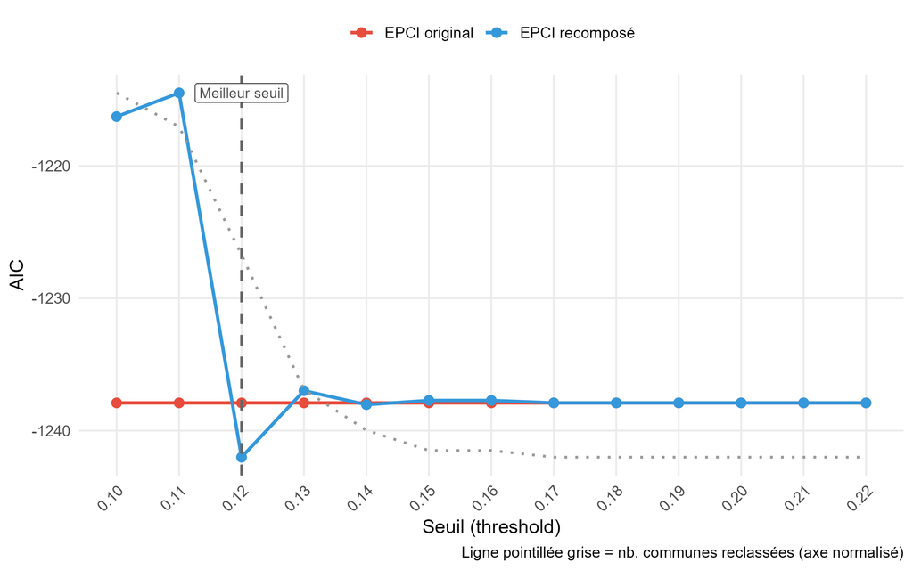

Figure 5 : Graphique des différences d’AIC des modèles multiniveaux selon le seuil de reclassification

## 5.2 Corrélation entre le nombre d’unités reclassées et la diminution de l’AIC : l’intérêt de regarder les seuils hors tendance

Il existe bien une corélation positive relativement importante entre le nombre de communes reclassées par `spatialRegroup` et le gain d’AIC obtenu dans le modèle multiniveau sur les EPCI regroupés (figure 6) : à partir d’un certain seuil, l’algorithme déplace des communes qui n’étaient pas vraiment mal classées, perturbant des groupes qui étaient en réalité cohérents. Toutefois, cette relation n’est pas nécessairement linéaire, ni même monotone, et c’est justement dans les écarts que réside un intérêt analytique. Si l’on admet que des reclassifications massives tendent en moyenne à dégrader l’ajustement multiniveau, les groupes initiaux étant globalement cohérents, alors les configurations qui s’écartent de cette tendance en produisant une amélioration acquièrent une signification propre : elles signalent les seuls paramétrages pour lesquels l’algorithme a identifié des unités incohérentes avec leur groupe d’appartenance.

Cela peut indiquer soit une zone de transition progressive sans rupture attributaire nette (la frontière est “floue” et déplacer des unités ne résout rien parce qu’il n’existe pas de bonne solution franche), soit une hétérogénéité interne aux groupes cibles qui annule les bénéfices attendus de la réassignation (même si la commune transférée ressemble davantage à ses nouveaux voisins frontaliers, elle ne ressemble pas au groupe dans son ensemble).

L’observation de ces écarts permet ainsi de passer d’une logique de correction globale de la partition à une géographie des effets de frontière : elle permet l’identification des paramétrages, et par extension les configurations territoriales, pour lesquels la frontière institutionnelle est la plus “onéreuse” en termes de modélisation.

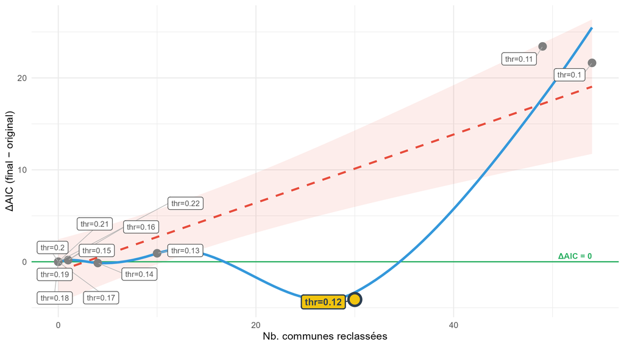

Figure 6 : Graphique des différences d’AIC pour chaque seuil en fonction du nombre de communes reclassées

Sur la base de cette double exploration, le seuil de 0,12 est retenu pour le regroupement final dans le cas de cette application. Ce paramètre présente le résidu le plus négatif par rapport à la droite de régression entre nombre de reclassifications et gain d’AIC : à nombre de communes reclassées équivalent, il produit la meilleure amélioration de l’ajustement multiniveau relativement à ce que prédit la tendance moyenne. Il représente ainsi le point où la correction locale est la plus efficiente : quelques transferts ciblés suffisent à résoudre les principales incohérences attributaires aux frontières intercommunales, sans que le volume de reclassifications ne devienne contre-productif.

# 6 Représentation cartographique du regroupement

```r
# Sélection des variables de regroupement : coefficients bêta de la MGWR
vars_attr <- c("coef_prix","coef_revenu", "coef_equip")

# Fonction principale
res_avance <- spatialRegroup(
      data            = df_final3,        # données sf avec géométrie
      group_var       = "EPCI",           # variable définissant la partition administrative initiale
      vars_attr       = vars_attr,        # vecteur des variables attributaires de regroupement
      method          = "euclidean",      # métrique de dissimilarité entre unités spatiales
      threshold       = 0.12,             # seuil minimal d'affinité pour être candidat à la reclassification
      standardize     = TRUE,             # standardisation des variables avant calcul des distances
      iterations      = 10,               # nombre maximum de passes de reclassification
      min_group       = 2,                # taille minimale d'un groupe pour être une destination valide
      nb_type         = "rook",           # (ou queen) règle de contiguïté
      remove_isolates = TRUE,             # réintègre les unités isolées après reclassification dans leur groupe d'origine
      weights         = c(0.1, 0.1, 0.1), # pondération de chaque variable attributaire
      local_profile   = T,                # affinité calculée sur les voisins adjacents ou sur le centroïde global du groupe
      cohesion_tol    = 0.001,            # seuil d'arrêt anticipé si le gain de cohésion devient inférieur à cette valeur
      verbose         = F                 # désactive l'affichage des messages de progression
)

# Intégration des nouveaux groupes au fichier original
df_final_2 <- res_avance |>
  mutate(
    EPCI_final = if_else(candidate, as.character(EPCI_regroup), as.character(EPCI))
  )
```

```r
tmap_mode("view")

df_final_2 <- st_as_sf(df_final_2)

# Objet allégé pour tmap uniquement
df_final_2_map <- df_final_2 |>
  dplyr::select(EPCI, EPCI_final, geometry)

# Filtrer les communes reclassées
reclassees <- res_avance |>
  dplyr::filter(EPCI != EPCI_regroup) |>
  dplyr::select(EPCI, EPCI_regroup, geometry)

# Carte 1 : EPCI originaux
tm1 <- tm_shape(df_final_2_map) +
  tm_polygons(
    col = "EPCI",
    palette = "Set3",
    border.col = "grey",
    lwd = 0.1,
    legend.show = FALSE
  ) +
  tm_layout(title = "EPCI Originaux")

# Carte 2 : EPCI finaux avec mise en évidence
tm2 <- tm_shape(df_final_2_map) +
  tm_polygons(
    col = "EPCI_final",
    palette = "Set3",
    border.col = "grey60",
    lwd = 0.1,
    legend.show = FALSE
  ) +
  tm_shape(reclassees) +
  tm_borders(col = "red", lwd = 1) +
  tm_layout(title = "Carte des EPCI regroupés après reclassement")

# Affichage côte à côte
carte_reg <- tmap_arrange(tm1, tm2)
```

[interactive chart not shown]

Figure 7 : Cartes des communes et leurs EPCI d’appartenance (avant et après regroupement)

La comparaison cartographique permet de visualiser l’amplitude et la localisation des reclassements opérés par `spatialRegroup` pour un seul de 0,12. La carte de gauche représente la partition intercommunale administrative initiale ; la carte de droite présente la partition recomposée, en mettant en évidence par un liseré rouge les communes effectivement reclassées. Ces unités, toutes situées en position frontalière entre deux EPCI contigus, présentaient un profil de comportement fiscal, tel que capturé par les coefficients locaux de la MGWR, statistiquement plus proche de l’EPCI voisin que de leur groupement d’appartenance initial. La structure d’ensemble de la carte reste visuellement quasi inchangée, ce qui est cohérent avec la logique de correction locale de l’algorithme : seules les unités pour lesquelles l’incohérence attributaire est avérée sont concernées, les groupes intérieurs restant intacts.

# 7 Validation du regroupement

```r
# Modèle EPCI original
m1 <- lme4::lmer(
    log_Taux_TFB_2024 ~ log_median + log_prix_m2_moy + log_moy_equip +  (1  | EPCI),
    data = df_final_2,
    REML = F)

# Modèle EPCI regroupés
m2 <- lme4::lmer(
    log_Taux_TFB_2024 ~ log_median + log_prix_m2_moy + log_moy_equip + (1  | EPCI_final),
    data = df_final_2,
    REML = F)

# Tableau des résultats
tab_model(
  m1,m2,
  dv.labels = c("EPCI originaux", "EPCI regroupés"),
  show.re.var = TRUE,
  show.icc = TRUE,
  show.r2 = TRUE,
  show.aic = TRUE,
  digits.re = 3,
  digits = 3
)
```

|  | EPCI originaux |  |  | EPCI regroupés |  |  |
| --- | --- | --- | --- | --- | --- | --- |
| Predictors | Estimates | CI | p | Estimates | CI | p |
| (Intercept) | 4.629 | 3.867 – 5.391 | **<0.001** | 4.784 | 4.026 – 5.542 | **<0.001** |
| log median | -0.150 | -0.237 – -0.063 | **0.001** | -0.158 | -0.245 – -0.072 | **<0.001** |
| log prix m2 moy | 0.029 | -0.037 – 0.095 | 0.385 | 0.020 | -0.045 – 0.086 | 0.543 |
| log moy equip | 0.079 | 0.065 – 0.093 | **<0.001** | 0.079 | 0.065 – 0.093 | **<0.001** |
| Random Effects |  |  |  |  |  |  |
| σ<sup>2</sup> | 0.018 |  |  | 0.018 |  |  |
| τ<sub>00</sub> | 0.036 <sub>EPCI</sub> |  |  | 0.036 <sub>EPCI_final</sub> |  |  |
| ICC | 0.673 |  |  | 0.672 |  |  |
| N | 62 <sub>EPCI</sub> |  |  | 62 <sub>EPCI_final</sub> |  |  |
| Observations | 1250 |  |  | 1250 |  |  |
| Marginal R<sup>2</sup> / Conditional R<sup>2</sup> | 0.121 / 0.712 |  |  | 0.118 / 0.711 |  |  |
| AIC | -1237.896 |  |  | -1242.001 |  |  |

Tableau 3 : Résultats des modèles multiniveaux EPCI originaux et EPCI regroupés.

Les deux modèles multiniveaux incluent comme effets fixes les trois déterminants socio-économiques retenus dans la MGWR (log du revenu médian, log du prix moyen au m², log du nombre d’équipements), ce qui permet d’isoler l’effet institutionnel de l’appartenance à un EPCI de la simple hétérogénéité des caractéristiques communales. Le modèle de référence (EPCI originaux) attribue 67,3 % de la variance résiduelle du log-taux de TFPB à l’échelon intercommunal (ICC = 0,673). Ce résultat confirme que l’appartenance à un EPCI structure très fortement les niveaux de fiscalité foncière, indépendamment des caractéristiques communales : une large majorité de la variabilité observée entre communes s’explique par leur groupement intercommunal plutôt que par leurs profils socio-économiques propres.

# 8 Conclusion

L’application présentée dans cet article illustre un cas d’usage de `spatialRegroup`: celui d’un découpage administratif dont la cohérence statistique est globalement valide mais qui présente, aux frontières, certaines unités dont le rattachement institutionnel ne correspond pas au comportement fiscal observé. En identifiant précisément ces unités, `spatialRegroup` agit comme un instrument de détection des **effets de frontière micro-locaux** : là où les approches classiques testent l’existence d’une discontinuité le long d’une frontière entière, le package localise commune par commune les segments de frontière où cette discontinuité est effectivement attributaire. Les communes candidates constituent ainsi une cartographie des zones de friction : des zones où l’appartenance d’un objet à un groupement institutionnel plutôt qu’un autre produit une incohérence statistiquement observable, indépendamment des caractéristiques socio-économiques individuelles.

L’intérêt de `spatialRegroup` dépasse le seul cas des découpages administratifs institutionnels. Le package est également mobilisable pour évaluer et corriger des partitions construites par des méthodes *data-driven* (classifications non supervisées, typologies territoriales, zonages produits par k-means ou classification ascendante hiérarchique) pour lesquelles les frontières entre groupes sont définies par des seuils statistiques plutôt que par des limites institutionnelles. Dans ces contextes, les unités situées à la frontière de deux classes peuvent présenter des profils ambigus que l’algorithme initial a du mal à trancher ; `spatialRegroup` donne un moyen systématique d’identifier ces unités et de tester si leur réassignation améliore la cohérence locale de la partition. Il constitue en ce sens un outil de *correction locale* complémentaire aux méthodes de classification, applicable à tout contexte où des unités spatiales sont agrégées en groupes et où la contiguïté géographique est une contrainte pertinente.

## Les références

Assunção, R. M., Neves, M. C., Câmara, G. et Freitas, C. da C. (2006). Efficient regionalization techniques for socio-economic geographical units using minimum spanning trees. *International Journal of Geographical Information Science*, *20*(7), 797‑811. https://doi.org/10.1080/13658810600665111

Briant, A., Lafourcade, M. et Schmutz, B. (2015). Can Tax Breaks Beat Geography? Lessons from the French Enterprise Zone Experience. *American Economic Journal: Economic Policy*, *7*(2), 88‑124.

Brunsdon, C., Fotheringham, A. S. et Charlton, M. E. (1996). Geographically Weighted Regression: A Method for Exploring Spatial Nonstationarity. *Geographical Analysis*, *28*(4), 281‑298. https://doi.org/10.1111/j.1538-4632.1996.tb00936.x

Chavent, M., Kuentz-Simonet, V., Labenne, A. et Saracco, J. (2018). ClustGeo: an R package for hierarchical clustering with spatial constraints. *Computational Statistics*, *33*(4), 1799‑1822. https://doi.org/10.1007/s00180-018-0791-1

Coombes, M. G., Green, A. E. et Openshaw, S. (1986). An efficient algorithm to generate official statistical reporting areas: the case of the 1984 Travel-to-Work Areas revision in Britain. *Journal of the Operational Research Society*, *37*(10), 943‑953. https://doi.org/10.1057/jors.1986.163

Duque, J. C., Anselin, L. et Rey, S. J. (2012). The max-p-regions problem. *Journal of Regional Science*, *52*(3), 397‑419. https://doi.org/10.1111/j.1467-9787.2011.00743.x

Fack, G. et Grenet, J. (2010). When do better schools raise housing prices? Evidence from Paris public and private schools. *Journal of Public Economics*, *94*(1-2), 59‑77.

Farmer, C. J. Q. et Fotheringham, A. S. (2011). Network-based functional regions. *Environment and Planning A*, *43*(11), 2723‑2741. https://doi.org/10.1068/a44136

Feuillet, T. (2021). *Les effets de contexte en géographie* [habilitation a diriger des recherches, Université Paris 8 Vincennes – Saint-Denis]. https://hal.science/tel-03357283

Feuillet, T., Cossart, E., Charreire, H., Banos, A. et Pilkington, H. (2024). *Hybridizing geographically weighted regression and multilevel models*. Document inédit. https://hal.science/hal-04378995

Fotheringham, A. S., Brunsdon, C. et Charlton, M. (2000). *Quantitative Geography: Perspectives on Spatial Data Analysis*. Sage.

Fotheringham, A. S., Brunsdon, C. et Charlton, M. (2002). *Geographically Weighted Regression: The Analysis of Spatially Varying Relationships*. Wiley.

Fotheringham, A. S., Yang, W. et Kang, W. (2017). Multiscale Geographically Weighted Regression (MGWR). *Annals of the American Association of Geographers*, *107*(6), 1247‑1265. https://doi.org/10.1080/24694452.2017.1352480

Guérois, M. et Le Goix, R. (2009). La dynamique spatio-temporelle des prix immobiliers à différentes échelles : le cas des appartements anciens à Paris (1990–2003). *Cybergeo: European Journal of Geography*, (470). https://doi.org/10.4000/cybergeo.22644

Guo, D. (2008). Regionalization with dynamically constrained agglomerative clustering and partitioning (REDCAP). *International Journal of Geographical Information Science*, *22*(7), 801‑823. https://doi.org/10.1080/13658810701674970

Klapka, P., Halás, M. et Tonev, P. (2013). Functional regions: Concept and types. *Proceedings of the 16th International Colloquium on Regional Sciences*, 94‑101. https://doi.org/10.5817/CZ.MUNI.P210-6257-2013-11

Li, X. et Anselin, L. (2022). *rgeoda: R Library for Spatial Data Analysis*. https://cran.r-project.org/package=rgeoda

Mangeney, C., Pilkington, H. et Feuillet, T. (2024). Distribution de la surmortalite Covid-19 intercommunalites franciliennes. *Espace Populations Societes*, *2023/3–2024/1*. https://doi.org/10.4000/12tpt

Mericskay, B. et Demoraes, F. (2022). Préparer et analyser les données de Demandes de valeurs foncières en open data : proposition d’une méthodologie reproductible. *Cybergeo: European Journal of Geography*. https://doi.org/10.4000/cybergeo.39583

Openshaw, S. (1984). The modifiable areal unit problem. *Concepts and Techniques in Modern Geography*, *38*.

Revelli, F. (2001). Spatial patterns in local taxation: tax mimicking or error mimicking? *Applied Economics*, *33*(9), 1101‑1107.

Tiebout, C. M. (1956). A pure theory of local expenditures. *Journal of Political Economy*, *64*(5), 416‑424.

Yu, H., Fotheringham, A. S., Li, Z., Oshan, T., Kang, W. et Wolf, L. J. (2020). Inference in Multiscale Geographically Weighted Regression. *Geographical Analysis*, *52*(1), 87‑106. https://doi.org/10.1111/gean.12189